# R Notebook

The purpose of this notebook is to train a toy model to demonstrate how R modeling can be tied in with web-based frontends. In this case, we will use a shapefile that contains latitudes, longitudes, and a number of demography variables for polygons around the US. These include Median Income, so we will construct a toy model by attempting to predict Median Income as a function of the remaining variables. The model we’ll be fitting is a simple [linear regression](http://r-statistics.co/Linear-Regression.html), which may or may not have predictive power in this case, but is simple to set up and use.

# Setup

## Libraries

The code below will attempt to require the given list of libraries, and automatically install any that are missing.

```r
set.seed(1)
sapply(c(
    'plumber',
    'tidyverse',
    'caret',
    'rgdal',
    'rgeos'
), function(p) {
    if (!requireNamespace(p, quietly = TRUE)) {
        install.packages(p, quiet = TRUE)
    }
    require(p, character.only = TRUE, quietly = TRUE)
})
```

[output not shown]

```
  plumber tidyverse     caret     rgdal     rgeos
     TRUE      TRUE      TRUE      TRUE      TRUE
```

```r
print("Libraries loaded.")
```

```
[1] "Libraries loaded."
```

## Reading in a Shapefile

For the purposes of this example, we’ll use the ‘2016 Population Density by Congressional District’ shapefile provided by the Esri Demographics team, which can be found at https://www.arcgis.com/home/item.html?id=ff48bbae433442a38f6c635b8c7baf72.

We’ve downloaded and unzipped it into the ‘files’ subdirectory, so we can now read it in using functions from R’s ‘RGDAL’ library.

```r
shapefile <- rgdal::readOGR(
    dsn = "files/2016_Population_Density_by_Congressional_District.shp",
    stringsAsFactors = FALSE
)
shapefile@data <- shapefile@data %>%
    mutate_at(
      vars(TOTPOP_CY:GenSilent), as.numeric
    )
df <- SpatialPointsDataFrame(gCentroid(shapefile, byid=TRUE), shapefile@data) %>%
  as.tibble() %>%
  select( colnames(.) %>% order ) %>%
  select( -OBJECTID, -ID, -NAME, -ST_ABBREV ) %>%
  select( x, y, everything())
head(df)
```

| x | y | ASSCDEG_CY | AVGFMSZ_CY | AVGFMSZ_FY | AVGHHSZ_CY | AVGHHSZ_FY | AVGHINC_CY | BACHDEG_CY | DIVORCD_CY | FAMGRW10CY | FAMGRWCYFY | FAMHH_CY | FAMHH_FY | FAMPOP_CY | FAMPOP_FY | FEMALES_CY | GED_CY | GenBoom | GenMil | GenSilent | GenX_1 | GenZ_1 | GQPOP_CY | GQPOP_FY | GRADDEG_CY | HHGRW10CY | HHGRWCYFY | HHPOP_CY | HHPOP_FY | … |
| --- | --- | --- | --- | --- | --- | --- | --- | --- | --- | --- | --- | --- | --- | --- | --- | --- | --- | --- | --- | --- | --- | --- | --- | --- | --- | --- | --- | --- | --- | --- |
| -87.76436 | 31.09881 | 40432 | 3.04 | 3.04 | 2.51 | 2.51 | 60344 | 73829 | 74045 | 0.74 | 0.81 | 191687 | 199572 | 583505 | 606687 | 368668 | 25771 | 174921 | 192299 | 70716 | 125902 | 153999 | 13266 | 13266 | 38624 | 0.89 | 0.89 | 704571 | 734633 | … |
| -86.07105 | 31.70781 | 39123 | 3.01 | 3.02 | 2.46 | 2.47 | 57535 | 64575 | 73934 | 0.25 | 0.16 | 184343 | 185833 | 555536 | 561345 | 358119 | 31334 | 163829 | 198552 | 66245 | 124496 | 147721 | 22755 | 22755 | 39803 | 0.40 | 0.25 | 678088 | 687137 | … |
| -85.70711 | 33.15582 | 37496 | 3.01 | 3.02 | 2.47 | 2.48 | 55791 | 59730 | 72482 | 0.59 | 0.57 | 187981 | 193421 | 565972 | 584538 | 365723 | 29720 | 169330 | 210477 | 64252 | 126777 | 147038 | 19166 | 19166 | 39602 | 0.76 | 0.70 | 698711 | 724846 | … |
| -87.20042 | 34.11950 | 40820 | 3.00 | 3.01 | 2.49 | 2.49 | 53854 | 47569 | 72622 | 0.10 | 0.10 | 191464 | 192436 | 574661 | 579170 | 352446 | 32814 | 173988 | 174948 | 74147 | 126242 | 145017 | 8609 | 8609 | 29929 | 0.25 | 0.19 | 685737 | 692949 | … |
| -86.71182 | 34.75388 | 38868 | 2.99 | 3.00 | 2.44 | 2.44 | 69509 | 93057 | 73410 | 0.74 | 0.72 | 194767 | 201874 | 582285 | 604824 | 366478 | 28365 | 173788 | 197622 | 68177 | 133395 | 148287 | 15326 | 15326 | 55623 | 0.90 | 0.82 | 705942 | 735375 | … |
| -86.71312 | 33.26345 | 36504 | 3.06 | 3.08 | 2.53 | 2.54 | 81627 | 103752 | 66592 | 0.41 | 0.53 | 191244 | 196372 | 586005 | 604255 | 362937 | 19631 | 164428 | 192150 | 63197 | 135548 | 154136 | 11630 | 11629 | 64651 | 0.55 | 0.61 | 697834 | 721299 | … |

Note that the shapefile data actually has Median Income data attached to it, so we can look at some summary statistics to get an idea of how it is actually distributed:

```r
summary(df$MEDHINC_CY)
```

```
   Min. 1st Qu.  Median    Mean 3rd Qu.    Max.
  26377   45929   52606   56424   63145  115459
```

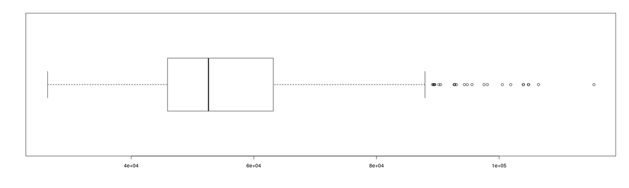

```r
boxplot(df$MEDHINC_CY, horizontal = TRUE)
```

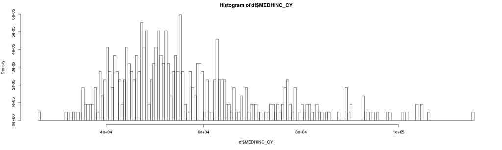

```r
hist(df$MEDHINC_CY, breaks = 250, freq = FALSE)
```

# Modeling

## Training

Before training the model, we do some slight preprocessing.

The first preprocessing step we’ll use is to remove columns that are linearly dependent - that is, columns that can be obtained by adding or subtracting multiples of other columns, making them redundant.

```r
dfClean <- df[, -caret::findLinearCombos(df)$remove]
print(GetoptLong::qq("Linearly dependent columns removed: @{ncol(df) - ncol(dfClean)}"))
```

```
[1] "Linearly dependent columns removed: 7"
```

Next, we’ll split the full dataset into a training set (90% of the data) and a holdout or testing set (the remaining 10%). This will allow us to assess the model’s accuracy by attempting to make predictions on the testing set, for which we know the actual response variable and can measure the difference.

```r
trainIndices <- createDataPartition(
  dfClean %>% pull(MEDHINC_CY),
  p = 0.90,
  list = FALSE,
  times = 1
)
training <- dfClean[ trainIndices,]
test  <- dfClean[-trainIndices,]
```

We’ll now fit a linear model to the training set. Here, we’re using the train function from caret, as it allows us to specify more preprocessing to be applied to the training data as well as future predictions.

The first argument is a formula, and in this case we’re specifying Median Income as a function of all remaining variables.

For preprocessing, we are centering and scaling the data so it has mean zero and standard deviation one. We also remove columns with near-zero variance (nzv), which tend to have be nearly constant across all of the training data, and then we apply a Yeo-Johnson transformation to stabilize the variance of the training data.

After training the linear model, we can examine the coefficients of each variable in the regression.

```r
lmFit <- caret::train(
  MEDHINC_CY ~ . ,
  data = training,
  method = "lm",
  preProcess = c("center", "scale", "nzv", "YeoJohnson")
)
print(lmFit$finalModel$coefficients)
```

```
  (Intercept)             x             y    ASSCDEG_CY    AVGFMSZ_CY    AVGFMSZ_FY    AVGHHSZ_CY    AVGHHSZ_FY
 5.629768e+04 -1.294490e+02  8.743697e+01  6.590427e+05 -1.092625e+04  8.031102e+03  3.125808e+03  5.769507e+02
   AVGHINC_CY    BACHDEG_CY    DIVORCD_CY    FAMGRW10CY    FAMGRWCYFY      FAMHH_CY      FAMHH_FY     FAMPOP_CY
 1.258668e+04  2.143066e+06 -6.481264e+05  2.400138e+03 -6.375517e+03 -2.777553e+04  2.941530e+04  3.804757e+04
    FAMPOP_FY    FEMALES_CY        GED_CY       GenBoom        GenMil     GenSilent        GenX_1        GenZ_1
-4.585048e+04  5.738520e+05  5.095419e+05 -8.413754e+05 -1.204093e+06 -6.110196e+05 -4.822457e+05 -1.009596e+06
     GQPOP_CY      GQPOP_FY    GRADDEG_CY     HHGRW10CY     HHGRWCYFY      HHPOP_CY      HHPOP_FY      High_Inc
-1.881312e+06  1.829814e+06  1.878181e+06 -2.222072e+03  9.322429e+03 -2.600634e+05  3.610019e+04 -8.500101e+04
     HINC0_CY    HINC100_CY     HINC15_CY    HINC150_CY     HINC25_CY     HINC35_CY     HINC50_CY     HINC75_CY
-6.277633e+04 -5.111576e+04 -3.778316e+04  1.235239e+03 -3.310137e+04 -3.484502e+04 -3.491937e+04 -2.664327e+04
    HSGRAD_CY      MALES_CY    MARRIED_CY    MHIGRWCYFY    NEVMARR_CY       NOHS_CY      OWNER_CY      OWNER_FY
 1.867515e+06  5.797130e+05 -2.172713e+06 -7.323494e+02 -2.066740e+06  1.287995e+06 -3.216550e+06 -7.439092e+06
   OWNGRWCYFY        PCI_CY    PCIGRWCYFY       POP0_CY      POP10_CY      POP15_CY      POP20_CY      POP25_CY
 5.294415e+02 -7.899160e+03  2.995978e+02  1.736729e+05  1.440042e+05  4.070214e+05  6.805531e+05  5.420362e+04
     POP30_CY      POP35_CY      POP40_CY      POP45_CY       POP5_CY      POP50_CY      POP55_CY      POP60_CY
 5.346213e+04  2.713253e+04  1.627318e+04  1.137875e+04  1.561719e+05  1.850348e+04  1.756594e+04  1.912421e+04
     POP65_CY      POP70_CY      POP75_CY      POP80_CY    POPDENS_CY    POPDENS_FY    POPGRW10CY    POPGRWCYFY
 2.366193e+04  5.189730e+03 -1.534380e+03  3.819457e+02 -1.278296e+04  1.312190e+04 -3.774573e+02 -3.478009e+03
    RENTER_CY     RENTER_FY     SMCOLL_CY     SOMEHS_CY      TOTHH_CY      TOTHH_FY      TOTHU_CY      TOTHU_FY
-2.872136e+06 -6.690262e+06  1.287920e+06  8.484168e+05  2.762980e+06  6.204492e+06 -1.721333e+03  1.337068e+03
   WIDOWED_CY
-3.820054e+05
```

## Performance / Error

We can now measure the error in two ways - the training error and the test error.

The training error indicates how well the model predicts data it has already seen - or in other words, how well the model fits the training data. The testing error indicates how well the model might predict on new, unseen data.

```r
printStats <- function(y_true, y_pred) {
  print(GetoptLong::qq("MAE: @{MLmetrics::MAE(y_pred = y_pred, y_true = y_true) %>% round(4)}"))
  print(GetoptLong::qq("MAPE: @{MLmetrics::MAPE(y_pred = y_pred, y_true = y_true) %>% round(4)}"))
  print(GetoptLong::qq("RMSE: @{MLmetrics::RMSE(y_pred = y_pred, y_true = y_true) %>% round(4)}"))
  print(GetoptLong::qq("R^2: @{MLmetrics::R2_Score(y_pred = y_pred, y_true = y_true) %>% round(4)}"))
  print(GetoptLong::qq("Correlation: @{cor(y_pred, y_true)}"))
}
print('Training Error')
```

```
[1] "Training Error"
```

```r
printStats(
  y_true = training %>% pull(MEDHINC_CY),
  y_pred = predict(lmFit, training %>% select(-MEDHINC_CY))
)
```

```
[1] "MAE: 1070.7168"
[1] "MAPE: 0.0201"
[1] "RMSE: 1378.837"
[1] "R^2: 0.9918"
[1] "Correlation: 0.995908505802516"
```

```r
print('#############################')
```

```
[1] "#############################"
```

```r
print('Testing Error')
```

```
[1] "Testing Error"
```

```r
printStats(
  y_pred = predict(lmFit, test %>% select(-MEDHINC_CY)),
  y_true = test %>% pull(MEDHINC_CY)
)
```

```
[1] "MAE: 1145.5958"
[1] "MAPE: 0.02"
[1] "RMSE: 1403.1783"
[1] "R^2: 0.993"
[1] "Correlation: 0.99685903792505"
```

The error metrics used are: - MAE: [Mean Absolute Error](https://en.wikipedia.org/wiki/Mean_absolute_error) - MAPE: [Mean Absolute Percent Error](https://en.wikipedia.org/wiki/Mean_absolute_percentage_error) - $R^2$: [Coefficient of Determination](https://en.wikipedia.org/wiki/Coefficient_of_determination) - [Correlation](https://en.wikipedia.org/wiki/Correlation_and_dependence#Pearson's_product-moment_coefficient)

```r
readr::write_rds(lmFit, "files/linear_model.rds")
print('Model written to file')
```

```
[1] "Model written to file"
```